# WOSdocumentation

wkumler

April 23, 2019

## To be interlaced elsewhere:

TS= Topic TI= Title AU= Author AI= Author Identifiers GP= Group Author [Index] ED= Editor SO= Publication Name [Index] DO= DOI PY= Year Published CF= Conference AD= Address OG= Organization-Enhanced [Index] OO= Organization SG= Suborganization SA= Street Address CI= City PS= Province/State CU= Country/Region ZP= Zip/Postal Code FO= Funding Agency FG= Grant Number FT= Funding Text SU= Research Area WC= Web of Science Category IS= ISSN/ISBN UT= Accession Number PMID= PubMed ID ALL= All Fields

## WOS tool

As stated in the README, I’d like to be able to access the Web Of Science tools to do some data analysis myself.

Part of the trick here is getting an authentication without an authentication - fortunately, the WOS tools that came with the wos Python package allow us to request “lite” access, which produces an SID that we’ll try to steal. This is accessed via the system command “wos” and various flags.

To save the bash output as an accessible variable, we use the syntax from [Stack Overflow](https://stackoverflow.com/questions/4651437/how-do-i-set-a-variable-to-the-output-of-a-command-in-bash)

> In addition to backticks (`command`), you can use $(command), which I find easier to read, and allows for nesting.

> OUTPUT=“$(ls -1)" echo "${OUTPUT}”

### Attempt #1

```bash
#SID="$(wos --lite query 'AU=Wickham Hadley')"
#echo $SID
```

The code throws an error, but we’ve got the SID we needed!

```r
print(SID)
```

```
## Error in print(SID): object 'SID' not found
```

I was really hoping that I’d be able to access the SID variable automatically in the following R block, but no luck.

### Attempt #2

If we can’t access SID natively, perhaps we can export it as an environmental variable and access it otherwise?

```bash
#export SID="$(wos --lite query 'AU=Wickham Hadley')"
```

```r
Sys.getenv(SID)
```

```
## Error in Sys.getenv(SID): object 'SID' not found
```

No dice. Damn.

### Attempt #3: yes!

Okay, rather than fiddling with bash and python and other languages, let’s just make a system call within R. Only works in Ubuntu?

```r
#v <- system("wos --lite query 'AU=Wickham Hadley'") # Doesn't work: returns v empty

v <- system("wos --lite query 'AU=Wickham Hadley'", intern = T) #Works!

SID <- v[1]
SID <- gsub('Authenticated \\(SID: ', "", SID)
SID <- gsub(")", "", SID)

print(SID)
```

```
## [1] "7FMPfk3NF3ZuXMvDqFH"
```

Yay! So we’ve got an SID that we can use to access WOS lite.

```r
library(wosr)

pull_wos("AU=Wickham Hadley", sid = SID) # Throws an error - not authorized
```

```
## Error: User has no entitlement for this service level - WOKSearchPremium
```

```r
pull_wos("AU=Wickham Hadley", sid = SID, editions = "CCR") # Throws an error - not authorized
```

```
## Error: User has no entitlement for this service level - WOKSearchPremium
```

```r
query_wos("AU=Wickham Hadley", sid = SID) # Throws an error - not authorized
```

```
## Error: User has no entitlement for this service level - WOKSearchPremium
```

Damn. Looks like wosr is only set up to query paid data sets. Time to do it the long way!

We can construct our GET and POST requests manually. By looking into the wosr query_wos data, we can see how they’re doing it:

> response <- httr::POST(“http://search.webofknowledge.com/esti/wokmws/ws/WokSearch”, body = body, httr::add_headers(cookie = sprintf(“SID=%s”, sid)), ua(), …)

> body <- paste0(“WOS”, escape_query(query), " “, paste_eds(editions),”en10“)

Let’s try that with the different endpoint “http://search.webofknowledge.com/esti/wokmws/ws/WokSearchLite”, found [here](http://help.incites.clarivate.com/wosWebServicesLite/WebServicesLiteOverviewGroup/Introduction/serviceEndpointAddresses.html)

```r
library(httr)
library(XML)
library(xml2)

endpoint = "http://search.webofknowledge.com/esti/wokmws/ws/WokSearchLite"

query <- "AU=Knuth Donald" #This may break when passing an ampersand: see wosr:::escape_query

bod1 <- "<soapenv:Envelope xmlns:soapenv=\"http://schemas.xmlsoap.org/soap/envelope/\"\n    xmlns:woksearch=\"http://woksearch.v3.wokmws.thomsonreuters.com\">\n    <soapenv:Header/>\n    <soapenv:Body>\n    <woksearch:search>\n    <queryParameters>\n    <databaseId>WOS</databaseId>\n    <userQuery> "
bod2 <- " </userQuery>"
bod3 <- "<queryLanguage>en</queryLanguage>\n    </queryParameters>\n    <retrieveParameters>\n    <firstRecord>1</firstRecord>\n    <count>0</count>\n    </retrieveParameters>\n    </woksearch:search>\n    </soapenv:Body>\n    </soapenv:Envelope>"

body <- paste0(bod1, query, bod2, SID, bod3)

response <- POST(endpoint, body = body, add_headers(cookie = paste0("SID=", SID)), wosr:::ua())


raw_xml <- httr::content(response, as = "text")
unescaped_xml <- wosr:::unescape_xml(raw_xml)
unescaped_xml <- paste0("<x>", unescaped_xml, "</x>")
doc <- read_html(unescaped_xml)


query_id <- wosr:::parse_el_txt(doc, xpath = "//queryid")
rec_cnt <- wosr:::parse_el_txt(doc, xpath = "//recordsfound")
structure(list(query_id = as.numeric(query_id), rec_cnt = as.numeric(rec_cnt),
               sid = SID), class = "query_result")
```

```
## Matching records: NA
```

So that didn’t work, and is instead returning an Error 500 - server weirdness.

Possible problems:

1. The server knows that the SID is coming from different places
2. The request is poorly-formed
3. The server isn’t handling things correctly

Breaking things down a little, let’s try fixing the first problem. We’re going to use httr to obtain an SID instead of the system workaround above. This is also good practive with POST and checks that we’ve got some things figured out.

```r
endpoint = "http://search.webofknowledge.com/esti/wokmws/ws/WokSearchLite"

query <- "AU=Knuth Donald" #This may break when passing an ampersand: see wosr:::escape_query

bod1 <- "<soapenv:Envelope xmlns:soapenv=\"http://schemas.xmlsoap.org/soap/envelope/\"\n xmlns:woksearchlite=\"http://woksearchlite.v3.wokmws.thomsonreuters.com\"> <soapenv:Header/>    <soap:Body>\n    <woksearchlite:search>\n    <queryParameters>\n    <databaseId>WOS</databaseId>\n    <userQuery> "
bod2 <- " </userQuery>     <editions>\n     <collection>WOS</collection>/n     <edition>SCI</edition>\n    </editions>\n    <timeSpan>\n    <begin>2000-01-01</begin>\n    </end>2011-12-31</end>\n    </timespan>\n    <queryLanguage>en</queryLanguage>\n    </queryParameters>\n    <retrieveParameters>\n    <firstRecord>1</firstRecord>\n    <count>5</count>\n    </retrieveParameters>\n    </woksearchlite:search>\n    </soapenv:Body>\n    </soapenv:Envelope>"

body <- paste0(bod1, query, bod2)

response <- POST(endpoint, body = body, add_headers(cookie = paste0("SID=", SID)))
```

Still no luck, having updated all the URL pieces to the proper spots. Let’s push ahead with the proper authorize procedure.

```r
endpoint <- "http://search.webofknowledge.com/esti/wokmws/ws/WOKMWSAuthenticate"

body <- '<soapenv:Envelope xmlns:soapenv="http://schemas.xmlsoap.org/soap/envelope/"\n    xmlns:auth="http://auth.cxf.wokmws.thomsonreuters.com">\n    <soapenv:Header/>\n    <soapenv:Body>\n        <auth:authenticate/>\n    </soapenv:Body>\n    </soapenv:Envelope>'

response <- POST(endpoint, body = body)

raw_SID = response$headers$`set-cookie`
SID = gsub("SID=", "", raw_SID)
```

So that worked - status code 200, SID returned as a cookie header. Cool!

The next step appears to be to run a search for a query, followed by a request for the searched resource.

```r
endpoint <- "http://search.webofknowledge.com/esti/wokmws/ws/WokSearchLite"

query <- "AU=Keleman P*"
#query <- "TS=(cadmium OR lead)"

bod1 <- '<soapenv:Envelope xmlns:soapenv="http://schemas.xmlsoap.org/soap/envelope/"\n    xmlns:woksearchlite="http://woksearchlite.v3.wokmws.thomsonreuters.com">\n    <soapenv:Header/>\n    <soapenv:Body>\n    <woksearchlite:search>\n    <queryParameters>\n    <databaseId>WOS</databaseId>\n    <userQuery>'

#bod2 <- '</userQuery>\n    <editions>\n    <collection>WOS</collection>\n    <edition>SCI</edition>\n    </editions>\n    <timeSpan>\n    <begin>2000-01-01</begin>\n    <end>2011-12-31</end>\n    </timeSpan>\n    <queryLanguage>en</queryLanguage>\n    </queryParameters>\n    <retrieveParameters>\n    <firstRecord>1</firstRecord>\n    <count>5</count>\n    </retrieveParameters>\n    </woksearchlite:search>\n    </soapenv:Body>\n    </soapenv:Envelope>'

bod2 <- '</userQuery>\n    <timeSpan>\n    <begin>1900-01-01</begin>\n    <end>2050-12-31</end>\n    </timeSpan>\n    <queryLanguage>en</queryLanguage>\n    </queryParameters>\n    <retrieveParameters>\n    <firstRecord>1</firstRecord>\n    <count>100</count>\n    </retrieveParameters>\n    </woksearchlite:search>\n    </soapenv:Body>\n    </soapenv:Envelope>'

body <- paste0(bod1, query, bod2)

response <- POST(endpoint, body = body, add_headers(cookie=paste0("SID=", SID)))

doc <- wosr:::get_xml(response)
query_id <- wosr:::parse_el_txt(doc, xpath = "//queryid")
rec_cnt <- wosr:::parse_el_txt(doc, xpath = "//recordsfound")
structure(list(query_id = as.numeric(query_id), rec_cnt = as.numeric(rec_cnt),
               sid = SID), class = "query_result")
```

```
## Matching records: 8
```

Also working! Awesome. Curiously, querying AU seems to be different from querying topics:

- AU=Knuth Donald: 1 matching record
- AU=Koehl Mimi: 0 matching records
- AU=Smith John: 249 matching records

Are those the number of unique authors with that name? And therefore Mimi doesn’t show up at all?

UPDATE: Modifying the parameters passed to the request recovers all 12 of Mimi’s papers that show up when interacting with the WOS GUI. Yay! I removed the time range and the editions tags.

- AU=Knuth Donald: 7 matching records
- AU=Koehl Mimi: 12 matching records (Mostly chapters from her book)
- AU=Koehl MAR: 149 matching records

Final step: retrieve information associated with the queried records!

```r
endpoint <- "http://search.webofknowledge.com/esti/wokmws/ws/WokSearchLite"

query_id <-  wosr:::parse_el_txt(wosr:::get_xml(response), xpath = "//queryid")
query_id
```

```
## [1] "1"
```

```r
bod1 <- '<soap:Envelope xmlns:soap="http://schemas.xmlsoap.org/soap/envelope/">\n    <soap:Body>\n    <ns2:retrieve xmlns:ns2="http://woksearchlite.v3.wokmws.thomsonreuters.com">\n    <queryId>'
bod2 <- '</queryId>\n    <retrieveParameters>\n    <firstRecord>1</firstRecord>\n    <count>100</count>\n    </retrieveParameters>\n    </ns2:retrieve>\n    </soap:Body>\n    </soap:Envelope>'

#<sortField>TC</sortField>\n would be nice to integrate, but may need to be added in the OG search

body <- paste0(bod1, query_id, bod2)

response <- POST(endpoint, body = body, add_headers(cookie=paste0("SID=", SID)))

response$status_code
```

```
## [1] 200
```

```r
raw_xml <- httr::content(response, as = "text")
unescaped_xml <- wosr:::unescape_xml(raw_xml)
unescaped_xml <- paste0("<x>", unescaped_xml, "</x>")
read_html(unescaped_xml)
```

```
## {xml_document}
## <html>
## [1] <body><x><envelope xmlns:soap="http://schemas.xmlsoap.org/soap/envel ...
```

```r
# sink(file = "unescaped_xml.txt")
# unescaped_xml
# sink()

raw_titles <- xml_text(xml_find_all(doc, xpath = "//title"))
titles <- gsub("^Title", "", raw_titles)
```

Sweet. We’ve accessed publications, extracted their titles… let’s visualize them!

```r
library(tm)
```

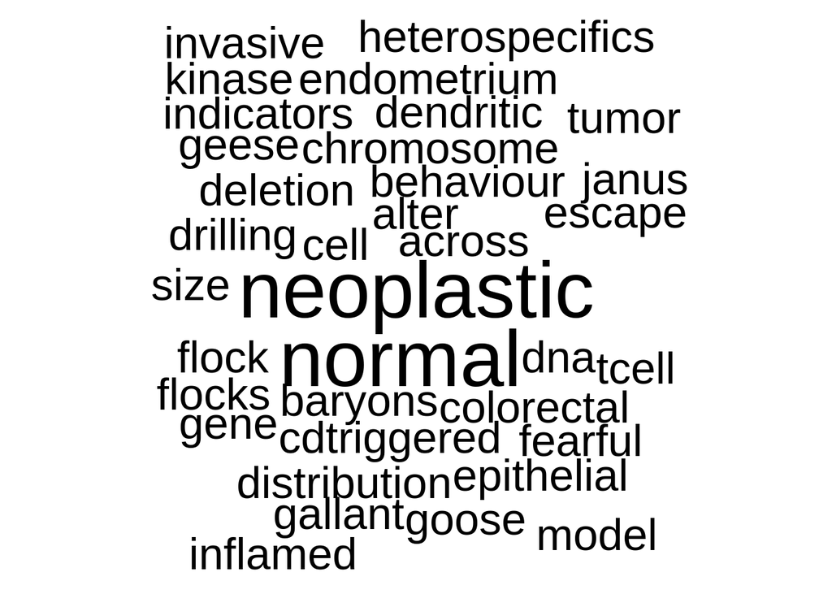

```r
library(SnowballC)
library(wordcloud)
wordiness <- sapply(X = titles, FUN = strsplit, " ")
names(wordiness) <- NULL
wordiness <- unlist(wordiness)
docs <- VCorpus(VectorSource(wordiness))

# Convert the text to lower case
docs <- tm_map(docs, content_transformer(tolower))
# Remove numbers
docs <- tm_map(docs, removeNumbers)
# Remove english common stopwords
docs <- tm_map(docs, removeWords, stopwords("english"))
# Remove your own stop word
# specify your stopwords as a character vector
docs <- tm_map(docs, removeWords, c("blabla1", "blabla2"))
# Remove punctuations
docs <- tm_map(docs, removePunctuation)
# Eliminate extra white spaces
docs <- tm_map(docs, stripWhitespace)
# Text stemming
# docs <- tm_map(docs, stemDocument)

dtm <- TermDocumentMatrix(docs)
m <- as.matrix(dtm)
v <- sort(rowSums(m),decreasing=TRUE)
d <- data.frame(word = names(v),freq=v)

wordcloud(words = d$word, freq = d$freq, min.freq = 1,
          random.order = F, rot.per = 0, max.words = 200)
```